# 分类器与预测器

### 1. 什么是学习？

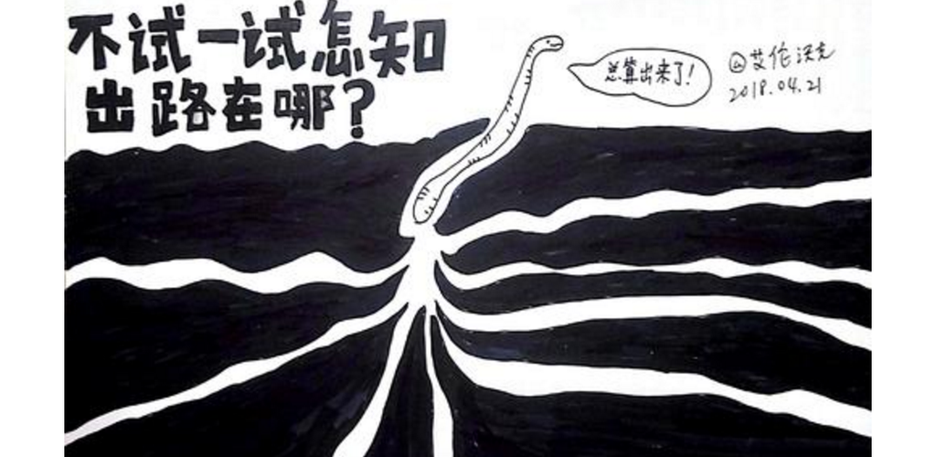

在之前的一讲中，我们了解了什么是神经网络，以及如何构建一个简单的人工神经网络。很可能有些同学已经跃跃欲试地准备编写代码搭建自己的神经网络，并训练自己的神经网络完成学习任务了。

但是呢，为了更好地帮助大家理解一个神经网络是如何进行“学习”的，我们先把编程的事情放一放，从“学习”这个概念的最基本定义开始讲起。

我们不妨先来玩一个游戏，同时来体会一下学习过程：

[figure not shown]

嗯，这款优秀的游戏叫做愤怒的小鸟。

这款游戏的故事相当有趣，为了报复偷走鸟蛋的肥猪们，鸟儿以自己的身体为武器，仿佛炮弹一样去攻击肥猪们的堡垒。

看着愤怒的红色小鸟，奋不顾身的往绿色的肥猪的堡垒砸去，那种奇妙的感觉还真是令人感到很欢乐。

鸟儿的弹出角度和力度由你的手指来控制，要注意考虑好力度和角度的综合计算，这样才能更准确的砸到肥猪。

一开始你并不能确定投掷的角度。不过没关系，你决定先试一把。

被弹出的鸟儿会留下弹射轨迹，为角度和力度的调整提供了依据。

如果角度太高了呢，那就低一些。

如果力度太大了呢，那就小一些。

于是，总有某一次（如果你不是和我一样菜），当你把弹弓上的小鸟弹出去，对面的肥猪全部被砸到，于是你顺利过关。

请你思考以下你是如何学会了鸟儿弹射的角度和力度：

首先，你进行试错。

然后，你观察试错的结果。

接着，你将目标（肥猪）和小鸟实际飞行的路线进行误差分析。

进而，你根据误差分析反向地调整自己的角度和力度模型，重新进行试错。

这就是我们人类进行“学习”这项工作的重要（而不唯一！）方式之一——试错法。用一张图总结如下：

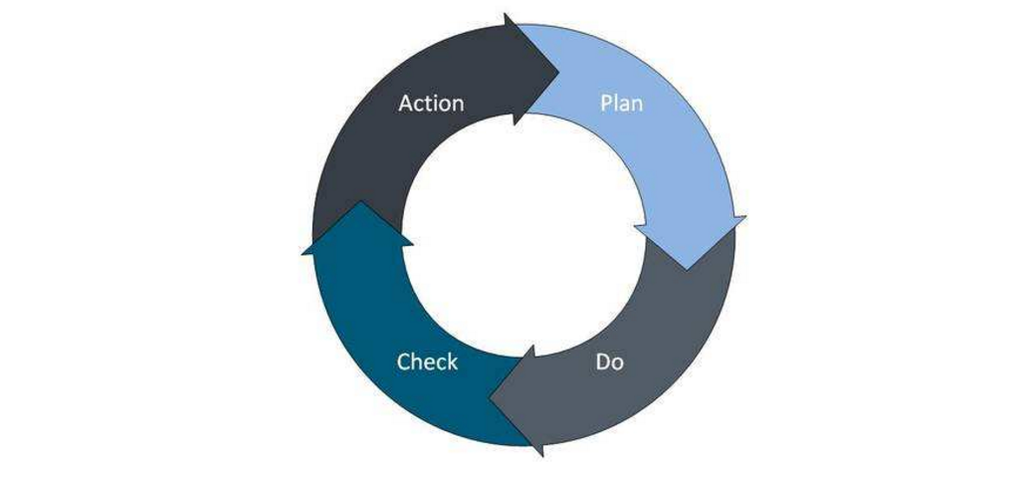

### 2. 训练简单的分类器进行学习

下面我们来用一个虫虫的例子，来学习一种降低误差的重要方法。

春天，你在公园里发现了2种虫子，一种是毛毛虫，另一种是瓢虫。

你很容易地就分清了哪个是毛虫哪个是瓢虫。

现在我们建立一个分类器，让计算机根据虫虫的简单参数也成预测出这只虫虫的类别。

我们选用的参数是虫虫的长和宽。

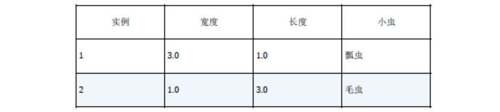

根据这组数据，建立一个直角坐标系。把毛虫和瓢虫画在这个坐标系上。

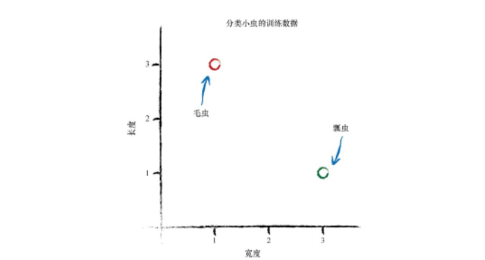

我们用试着让计算机找出一条分界线，在坐标系上把毛虫和瓢虫分开。为了简单采用只有一个参数的线性函数。

$ y = Ax $

容易察觉到，这里唯一的参数A控制着直线的斜率。较大的A对应着较大的斜率。

第一步，试错：

我们尝试从A = 0.25开始，分界线为y = 0.25x。在与训练数据的同一 张图中，我们绘制这条直线，观察一下这是一种什么情况。

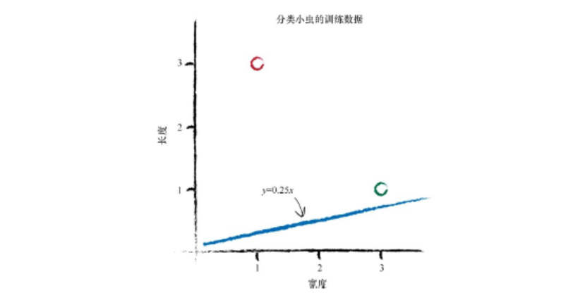

很明显，这并不是一台很好的分类器。因为这条直线并没有把两种类型的虫虫区分开。

我们需要修改这个参数。

那么如何修改呢？

观察已有的样本数据：瓢虫的宽度为3长度为1

把这个数据代入 $ y = 0.25 * x $ 中,得到预测的虫的长为 0.75。

我们希望的目标是什么呢？观察图片，如果当宽度为3.0时，长度比1.0更大（如1.1,1.2,1.3啥的）那么这条直线就能把虫虫分开了。

将预测与目标对比，我们知道这个预测的数字太小了。

##### 误差值 =（ 期望目标值 - 实际输出值 ）

现在，我们需要对这个E做些什么，才能更好地指导我们调整参数A 呢？

我们先从分类器的线性函数开始：

$ y = Ax $

我们知道，A的初始猜测值给出了错误的y值，y值应该等于训练数据 给定的值。我们将正确的期望值t称为目标值。为了得到t值，我们需要稍微调整A的值。数学家使用增量符号Δ表示“微小的变化量”。下面我们将这个变化量写出来：

$ t = (A + ΔA)x $

画出图来就是这样：

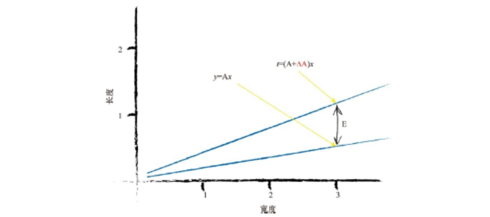

请记住，误差值E是期望的正确值与基于A的猜测值计算出来的值之间 的差值。也就是说，E等于t-y 。

$ E = (ΔA)x $

现在让我们来改进A ， 重新计算一下误差。

之前说过，根据第一个数据点提供的信息，目标y只要比1.0大就行。

然而在实际操作中，我们并不希望这个值太大（A万一超过了3.0岂不是还要往回调。）于是我们采取“适度的改进”。

在机器学习中，适度的改进（moderate）是一个重要的思路。

我们采用ΔA几分之一的一个变化值，而不是采用整个ΔA，充满激情地跳跃到每一个新的A值。使用这种方法，我们小心谨慎地向训练样本所指示的方向移动。

我们使用一个调节系数：

$ ΔA= L（E / x ）$

调节系数通常被称为学习率（learning rate），在此，我们称之为L。

在上面的例子中，我们先用L=0.5作为合理的学习率。

L=0.5，我们使用第一个样本（3.0 1.0）进行第一次训练：

初始值A = 0.25。使用第一个训练样本，我们得到y = 0.25 * 3.0 = 0.75，期望值为1.1，得到了误差值0.35。

$ ΔA = L（E / x ）= 0.5 * 0.35 / 3.0 = 0.0583 $

更新后的A值为0.25 + 0.0583 = 0.3083。

继续使用第二个样本（1.0 3.0）进行第二次训练：

当x = 1.0时，使用A = 0.3083，得到y = 0.3083 * 1.0 = 0.3083。所需值为2.9（要比3.0小），因此误差值是2.9-0.3083=2.5917。

$ ΔA = L（E / x ）= 0.5 * 2.5917 / 1.0 = 1.2958 $

第二个更新的值A等于0.3083 + 1.2958 = 1.6042。

这种有节制的调整，还带来了一个好处。当训练数据本身不能确信为完全正确并且包含在现实世界测量中普遍出现的错误或噪声时，有节制的调整可以抑制这些错误或噪声的影响。这种方法使得错误或噪声得到了调解和缓和。

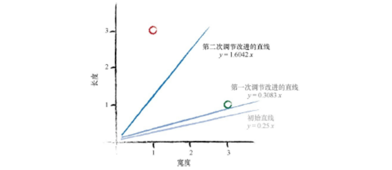

最终的训练结果真的很不错！

在将今天学到的知识应用于真正的神经网络训练之前，我们先来总结一下：

### 本章要点

1. 试错学习法是指追求目标的通过不断试验和降低误差，探索具有黑箱性质的系统的方法。
2. 我们使用线性分类器作为例子，理解了“目标”与“误差”
3. 使用朴素的调整方法会出现一个问题，即改进后的模型只与最后一次训练样本最匹配，“有效地”忽略了所有以前的训练样本。解决这个问题的一种好方法是使用学习率，调节改进速率，这样单一的训练样本就不能主导整个学习过程。
4. 使用学习率的另一个好处是：来自真实世界的训练样本可能充满噪声或包含错误。适度调整有助于限制这些错误样本的影响。